# Sberbank Springboard Capstone project

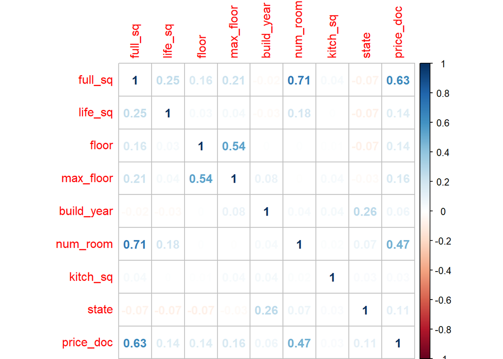

```r
# variables that are related to home
home <- c('full_sq', 'life_sq', 'floor', 'max_floor', 'build_year', 'num_room',
                    'kitch_sq', 'state', 'price_doc')

corrplot(cor(comb[, home], use="complete.obs"),method="number")
```

The strongest correlations are between price_doc and the full_sq and num_room features (which are also not surprisingly strongly correlated with each other).

```r
#Summarize potential house related features
summary(comb[home])
```

```
##     full_sq          life_sq           floor          max_floor
##  Min.   :  0.00   Min.   :   0.0   Min.   : 0.000   Min.   :  0.00
##  1st Qu.: 38.00   1st Qu.:  20.0   1st Qu.: 3.000   1st Qu.:  9.00
##  Median : 49.00   Median :  30.0   Median : 6.000   Median : 12.00
##  Mean   : 53.91   Mean   :  34.4   Mean   : 7.339   Mean   : 12.63
##  3rd Qu.: 63.00   3rd Qu.:  43.0   3rd Qu.:10.000   3rd Qu.: 17.00
##  Max.   :637.00   Max.   :7478.0   Max.   :77.000   Max.   :117.00
##                   NA's   :1705
##    build_year      num_room         kitch_sq            state
##  Min.   :   0   Min.   : 0.000   Min.   :   0.000   Min.   :1.000
##  1st Qu.:1967   1st Qu.: 1.000   1st Qu.:   5.000   1st Qu.:1.000
##  Median :1979   Median : 2.000   Median :   7.000   Median :2.000
##  Mean   :1893   Mean   : 1.926   Mean   :   7.097   Mean   :2.105
##  3rd Qu.:2005   3rd Qu.: 3.000   3rd Qu.:   9.000   3rd Qu.:3.000
##  Max.   :4965   Max.   :19.000   Max.   :2014.000   Max.   :4.000
##  NA's   :1646
##    price_doc
##  Min.   :  100000
##  1st Qu.: 5160754
##  Median : 6700000
##  Mean   : 7638857
##  3rd Qu.: 8914008
##  Max.   :95122496
##
```

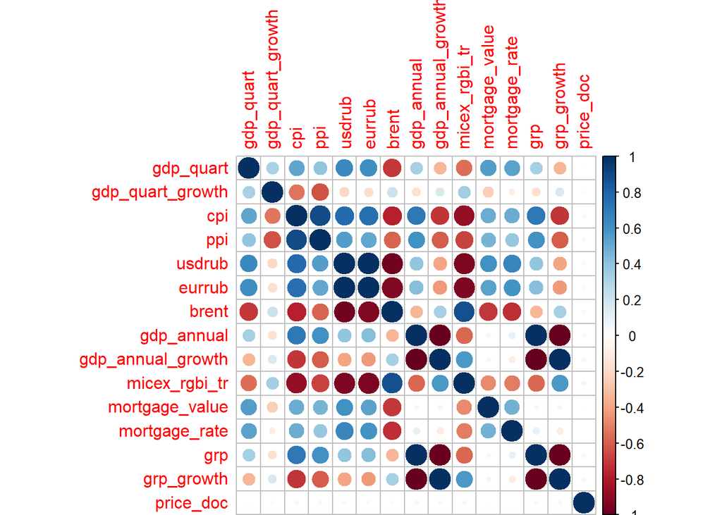

```r
# variables that are related to macroeconomic data
macro_var <- c('gdp_quart','gdp_quart_growth','cpi','ppi','usdrub','eurrub','brent','gdp_annual','gdp_annual_growth','micex_rgbi_tr','mortgage_value','mortgage_rate','grp','grp_growth','price_doc')

#,'gdp_annual','gdp_annual_growth','micex_rgbi_tr','mortgage_value','mortage_rate','grp','grp_growth','price_doc')
#cor(comb[,macro_var])
corrplot(cor(comb[, macro_var], use="complete.obs"))
```

There does not appear to be a strong correlation between the price_doc and the macroeconomic features examined above.

```r
#Summarize potential macroeconomic features
summary(comb[macro_var])
```

```
##    gdp_quart     gdp_quart_growth       cpi             ppi
##  Min.   :15892   Min.   :-2.8000   Min.   :390.4   Min.   :462.1
##  1st Qu.:18210   1st Qu.: 0.6000   1st Qu.:408.3   1st Qu.:487.9
##  Median :18885   Median : 0.9000   Median :422.8   Median :502.4
##  Mean   :18988   Mean   : 0.7074   Mean   :428.4   Mean   :506.6
##  3rd Qu.:20407   3rd Qu.: 1.3000   3rd Qu.:440.5   3rd Qu.:513.9
##  Max.   :21515   Max.   : 2.1000   Max.   :489.5   Max.   :575.9
##
##      usdrub          eurrub          brent          gdp_annual
##  Min.   :31.21   Min.   :40.31   Min.   : 46.59   Min.   :66927
##  1st Qu.:34.33   1st Qu.:46.63   1st Qu.: 70.54   1st Qu.:71017
##  Median :36.02   Median :49.13   Median :106.04   Median :71017
##  Mean   :41.53   Mean   :52.81   Mean   : 93.14   Mean   :71406
##  3rd Qu.:49.47   3rd Qu.:57.42   3rd Qu.:109.08   3rd Qu.:71017
##  Max.   :69.47   Max.   :84.96   Max.   :116.61   Max.   :77945
##
##  gdp_annual_growth  micex_rgbi_tr    mortgage_value    mortgage_rate
##  Min.   :0.007065   Min.   : 97.86   Min.   :  70259   Min.   :11.93
##  1st Qu.:0.012795   1st Qu.:119.75   1st Qu.: 333115   1st Qu.:12.23
##  Median :0.012795   Median :124.71   Median : 774624   Median :12.30
##  Mean   :0.015949   Mean   :123.72   Mean   : 795996   Mean   :12.63
##  3rd Qu.:0.012795   3rd Qu.:130.45   3rd Qu.:1215518   3rd Qu.:12.62
##  Max.   :0.035179   Max.   :139.37   Max.   :1753294   Max.   :14.71
##
##       grp          grp_growth       price_doc
##  Min.   :11815   Min.   :0.0841   Min.   :  100000
##  1st Qu.:12809   1st Qu.:0.0841   1st Qu.: 5160754
##  Median :12809   Median :0.0841   Median : 6700000
##  Mean   :12591   Mean   :0.0893   Mean   : 7638857
##  3rd Qu.:12809   3rd Qu.:0.0841   3rd Qu.: 8914008
##  Max.   :12809   Max.   :0.1076   Max.   :95122496
##  NA's   :2777    NA's   :2777
```

```r
#Build a simple linear regression model based on the structure related features
homelm <- lm(price_doc~.,comb[home])
#summarize model related information including R-Squared and Adjusted R-Squared
summary(homelm)
```

```
##
## Call:
## lm(formula = price_doc ~ ., data = comb[home])
##
## Residuals:
##       Min        1Q    Median        3Q       Max
## -87894791  -1331623    193956   1407975  61674251
##
## Coefficients:
##               Estimate Std. Error t value Pr(>|t|)
## (Intercept) -3.601e+06  1.893e+05 -19.020  < 2e-16 ***
## full_sq      1.474e+05  2.236e+03  65.919  < 2e-16 ***
## life_sq     -9.756e+02  5.038e+02  -1.937   0.0528 .
## floor        4.356e+04  7.383e+03   5.900 3.72e-09 ***
## max_floor    6.514e+03  6.277e+03   1.038   0.2994
## build_year   4.421e+02  8.372e+01   5.280 1.31e-07 ***
## num_room     1.048e+05  5.318e+04   1.971   0.0487 *
## kitch_sq    -7.187e+02  1.075e+03  -0.668   0.5040
## state        9.372e+05  4.164e+04  22.508  < 2e-16 ***
## ---
## Signif. codes:  0 '***' 0.001 '**' 0.01 '*' 0.05 '.' 0.1 ' ' 1
##
## Residual standard error: 3812000 on 14806 degrees of freedom
##   (2096 observations deleted due to missingness)
## Multiple R-squared:  0.4306, Adjusted R-squared:  0.4303
## F-statistic:  1400 on 8 and 14806 DF,  p-value: < 2.2e-16
```

```r
#Build a simple linear regression model based on structure with the above macroeconomic features also added in
modelfeatures <- c(home,macro_var) #combine above structure and macroeconomic related features
modelfeatures <- modelfeatures[-c(24)] # Remove second instance of price_doc in list
combinedlm <- lm(price_doc~.,comb[modelfeatures])
#Summarize combined model
summary(combinedlm)
```

```
##
## Call:
## lm(formula = price_doc ~ ., data = comb[modelfeatures])
##
## Residuals:
##       Min        1Q    Median        3Q       Max
## -89826520  -1281386    228578   1370973  51778505
##
## Coefficients: (3 not defined because of singularities)
##                     Estimate Std. Error t value Pr(>|t|)
## (Intercept)       -8.510e+05  6.051e+06  -0.141    0.888
## full_sq            1.506e+05  2.396e+03  62.874  < 2e-16 ***
## life_sq           -7.979e+02  4.876e+02  -1.636    0.102
## floor              4.232e+04  7.771e+03   5.446 5.25e-08 ***
## max_floor         -5.133e+03  6.656e+03  -0.771    0.441
## build_year         4.453e+02  9.241e+01   4.819 1.46e-06 ***
## num_room          -2.615e+04  5.610e+04  -0.466    0.641
## kitch_sq          -1.836e+02  1.252e+03  -0.147    0.883
## state              9.557e+05  4.433e+04  21.558  < 2e-16 ***
## gdp_quart         -2.034e+01  1.119e+02  -0.182    0.856
## gdp_quart_growth  -3.081e+04  2.898e+05  -0.106    0.915
## cpi                6.256e+02  1.715e+04   0.036    0.971
## ppi               -1.871e+03  8.412e+03  -0.222    0.824
## usdrub             6.170e+04  8.169e+04   0.755    0.450
## eurrub            -4.672e+04  6.008e+04  -0.778    0.437
## brent             -3.402e+03  1.363e+04  -0.250    0.803
## gdp_annual         6.104e+01  6.073e+01   1.005    0.315
## gdp_annual_growth         NA         NA      NA       NA
## micex_rgbi_tr     -1.739e+04  1.955e+04  -0.890    0.374
## mortgage_value    -2.058e-02  1.549e-01  -0.133    0.894
## mortgage_rate     -2.674e+05  2.780e+05  -0.962    0.336
## grp                       NA         NA      NA       NA
## grp_growth                NA         NA      NA       NA
## ---
## Signif. codes:  0 '***' 0.001 '**' 0.01 '*' 0.05 '.' 0.1 ' ' 1
##
## Residual standard error: 3676000 on 12481 degrees of freedom
##   (4410 observations deleted due to missingness)
## Multiple R-squared:  0.4379, Adjusted R-squared:  0.437
## F-statistic: 511.7 on 19 and 12481 DF,  p-value: < 2.2e-16
```

R-Squared improved slightly with the addition of macroeconomic features

Let’s see if we can improve results by adding in the geographic sub area as a feature in the model:

```r
modelfeatures <- c(modelfeatures,'sub_area') #add in sub_area feature to model
combinedlm <- lm(price_doc~.,comb[modelfeatures])
#Summarize combined model
summary(combinedlm)
```

```
##
## Call:
## lm(formula = price_doc ~ ., data = comb[modelfeatures])
##
## Residuals:
##       Min        1Q    Median        3Q       Max
## -88295064   -642791    482513   1231095  48461879
##
## Coefficients: (3 not defined because of singularities)
##                                          Estimate Std. Error t value
## (Intercept)                            -1.736e+06  5.392e+06  -0.322
## full_sq                                 1.465e+05  2.222e+03  65.915
## life_sq                                -5.357e+02  4.330e+02  -1.237
## floor                                   4.412e+04  6.994e+03   6.308
## max_floor                               2.891e+04  6.280e+03   4.603
## build_year                             -2.670e+02  8.725e+01  -3.061
## num_room                               -1.768e+05  5.092e+04  -3.473
## kitch_sq                                6.191e+02  1.111e+03   0.557
## state                                   5.478e+05  4.449e+04  12.313
## gdp_quart                               4.904e+01  9.954e+01   0.493
## gdp_quart_growth                       -1.494e+05  2.579e+05  -0.579
## cpi                                     4.018e+03  1.526e+04   0.263
## ppi                                     1.593e+02  7.485e+03   0.021
## usdrub                                 -7.633e+02  7.271e+04  -0.010
## eurrub                                  1.437e+04  5.348e+04   0.269
## brent                                  -2.546e+03  1.213e+04  -0.210
## gdp_annual                              4.446e+01  5.402e+01   0.823
## gdp_annual_growth                              NA         NA      NA
## micex_rgbi_tr                          -6.666e+03  1.737e+04  -0.384
## mortgage_value                         -3.746e-02  1.379e-01  -0.272
## mortgage_rate                          -2.216e+05  2.473e+05  -0.896
## grp                                            NA         NA      NA
## grp_growth                                     NA         NA      NA
## sub_areaAkademicheskoe                  8.681e+05  5.078e+05   1.709
## sub_areaAlekseevskoe                    2.273e+04  6.269e+05   0.036
## sub_areaAltuf'evskoe                   -2.721e+06  6.959e+05  -3.910
## sub_areaArbat                           8.040e+06  1.510e+06   5.325
## sub_areaBabushkinskoe                  -1.340e+06  6.158e+05  -2.176
## sub_areaBasmannoe                       1.332e+06  6.124e+05   2.175
## sub_areaBegovoe                         1.222e+06  7.185e+05   1.700
```

[output cut: 297 more lines]

```
## sub_areaVostochnoe                     0.075907 .
## sub_areaVostochnoe Degunino            9.79e-05 ***
## sub_areaVostochnoe Izmajlovo           0.000482 ***
## sub_areaVyhino-Zhulebino               9.45e-07 ***
## sub_areaZamoskvorech'e                 7.42e-10 ***
## sub_areaZapadnoe Degunino              1.94e-13 ***
## sub_areaZjablikovo                     4.68e-05 ***
## sub_areaZjuzino                        0.071331 .
## ---
## Signif. codes:  0 '***' 0.001 '**' 0.01 '*' 0.05 '.' 0.1 ' ' 1
##
## Residual standard error: 3252000 on 12337 degrees of freedom
##   (4410 observations deleted due to missingness)
## Multiple R-squared:  0.5652, Adjusted R-squared:  0.5595
## F-statistic: 98.39 on 163 and 12337 DF,  p-value: < 2.2e-16
```

Adding in the sub area of the property, perhaps unsurprisingly, results in a large increase in Adjusted R-Squared compared to the previous model.

Predict sales prices for the test dataset:

```r
predprice <- predict(combinedlm,newdata=combtest)
```